# Homework in SA23229024

Liu jingtao

2023-12-12

### HW0 2023/9/11

### Question

1，Go through “R for Beginners” if you are not familiar with R programming.

2，I Use knitr to produce at least 3 examples. For each example, texts should mix with figures and/or tables. Better to have mathematical formulas.

### Answer

### 1. The frist required example

# 自定义数据

```r
x <- rnorm(130)
y <- sin(cos(x))/x
```

# 使用 par 绘制相关图像

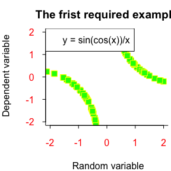

```r
opar <- par()

par(col.axis="red", mar=c(4, 4, 2.5, 0.25))

plot(x, y, main = "The frist required example",xlab=" Random variable", ylab=" Dependent variable",
xlim=c(-2, 2), ylim=c(-2, 2), pch=22, col="yellow", bg="green",bty="l", tcl=-.25, las=1, cex=1.5)

legend("topleft", legend = c("y = sin(cos(x))/x"),col = c("blue"))#标注数学公式
```

### 2. The second required example

# 采用自带的数据集

```r
data(mtcars)
```

# 使用 ggplot2 绘制相关图表

```r
library(ggplot2)
```

# 绘制散点图

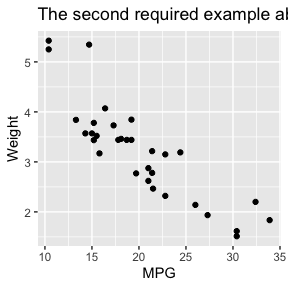

```r
ggplot(mtcars, aes(x = mpg, y = wt)) +
  geom_point() +
  xlab("MPG") +
  ylab("Weight") +
  ggtitle("The second required example about MPG vs. Weight")
```

```r
# 生成相关系数矩阵
cor_matrix <- cor(mtcars)
cor_matrix
```

```
##             mpg        cyl       disp         hp        drat         wt
## mpg   1.0000000 -0.8521620 -0.8475514 -0.7761684  0.68117191 -0.8676594
## cyl  -0.8521620  1.0000000  0.9020329  0.8324475 -0.69993811  0.7824958
## disp -0.8475514  0.9020329  1.0000000  0.7909486 -0.71021393  0.8879799
## hp   -0.7761684  0.8324475  0.7909486  1.0000000 -0.44875912  0.6587479
## drat  0.6811719 -0.6999381 -0.7102139 -0.4487591  1.00000000 -0.7124406
## wt   -0.8676594  0.7824958  0.8879799  0.6587479 -0.71244065  1.0000000
## qsec  0.4186840 -0.5912421 -0.4336979 -0.7082234  0.09120476 -0.1747159
## vs    0.6640389 -0.8108118 -0.7104159 -0.7230967  0.44027846 -0.5549157
## am    0.5998324 -0.5226070 -0.5912270 -0.2432043  0.71271113 -0.6924953
## gear  0.4802848 -0.4926866 -0.5555692 -0.1257043  0.69961013 -0.5832870
## carb -0.5509251  0.5269883  0.3949769  0.7498125 -0.09078980  0.4276059
##             qsec         vs          am       gear        carb
## mpg   0.41868403  0.6640389  0.59983243  0.4802848 -0.55092507
## cyl  -0.59124207 -0.8108118 -0.52260705 -0.4926866  0.52698829
## disp -0.43369788 -0.7104159 -0.59122704 -0.5555692  0.39497686
## hp   -0.70822339 -0.7230967 -0.24320426 -0.1257043  0.74981247
## drat  0.09120476  0.4402785  0.71271113  0.6996101 -0.09078980
## wt   -0.17471588 -0.5549157 -0.69249526 -0.5832870  0.42760594
## qsec  1.00000000  0.7445354 -0.22986086 -0.2126822 -0.65624923
## vs    0.74453544  1.0000000  0.16834512  0.2060233 -0.56960714
## am   -0.22986086  0.1683451  1.00000000  0.7940588  0.05753435
## gear -0.21268223  0.2060233  0.79405876  1.0000000  0.27407284
## carb -0.65624923 -0.5696071  0.05753435  0.2740728  1.00000000
```

```r
# 生成交叉表
table <- table(mtcars$gear, mtcars$cyl)
table
```

```
##
##      4  6  8
##   3  1  2 12
##   4  8  4  0
##   5  2  1  2
```

### 3. The third required example

# 数学公式

```r
formula_sqrt <- expression(y = sqrt(x)*sin(x))
```

# 创建数据

```r
x <- seq(-10, 100, by = 0.01)
```

# 绘制函数图像

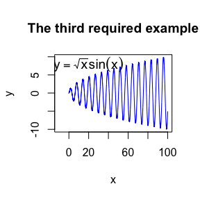

```r
plot(x, sqrt(x)*sin(x), type = "l", col = "blue",
     main = "The third required example",
     xlab = "x", ylab = "y")
text(20, 8, substitute(y == sqrt(x)*sin(x)), cex = 1.2)
```

### 4. The fourth example

# 自定义数据

```r
x <- rnorm(130)
y <- 1/(1+x^2)
```

# 使用 plot 绘制相关图像

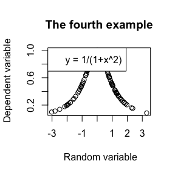

```r
plot(x,y,main = "The fourth example",xlab=" Random variable", ylab=" Dependent variable")
legend("topleft", legend = c("y = 1/(1+x^2)"), col = c("blue")) #标注数学公式
```

```r
# 加载bootstrap包和导入law数据
library(bootstrap)
library(boot)
data(law)

# 定义相关性统计量函数
cor_stat <- function(data, indices) {
  dt <- data[indices, ]
  cor(dt$LSAT, dt$GPA)
}
# bootstrap模拟
boot_out <- boot(data = law, statistic = cor_stat, R = 2000)

# 获取bootstrap样本计算的相关统计量
boot_corr <- boot_out$t

# 计算相关统计量的标准误差
se <- sqrt(var(boot_corr)/2000)

# 计算t分布的临界值
confidence_level <- 0.95
degrees_freedom <- 2000 - 1
t_critical <- qt((1 + confidence_level) / 2, df = degrees_freedom)

# 计算t置信区间估计的下限和上限
lower <- mean(boot_corr) - t_critical * se
upper <- mean(boot_corr) + t_critical * se

# 打印结果
cat("t置信区间估计:", round(lower, 4), "-", round(upper, 4))
```

```
## t置信区间估计: 0.7665 - 0.7782
```

```r
library(bootstrap)
data(law)

M <- 2000
n <- nrow(law)
R <- numeric(M)
for (i in 1:M){
   m <- sample(1:n,size= n,replace = TRUE)
   R[i] <- cor(law$LSAT[m],law$GPA[m])
}

t_result <- t.test(R)
# 获取t置信区间估计的下限和上限
lower <- t_result$conf.int[1]
upper <- t_result$conf.int[2]

# 打印结果
cat("t置信区间估计:", round(lower, 4), "-", round(upper, 4))
```

```
## t置信区间估计: 0.7623 - 0.7737
```

```r
library(boot)
data(law, package = "bootstrap")
boot.obj <- boot(law, R = 2000,statistic = function(x, i){cor(x[i,1], x[i,2])})
ci = boot.ci(boot.obj, type="t.ci")

ci$t
```

```
## [1] 0.7763745
```

### HW1 2023/9/18

### Question

1，用逆变化法实现sample函数的功能，其中（replace = TRUE）.

2，Exercis Statistical computing with R, M.L.Rizzo,res 3.2, 3.7, 3.9, 3.10 (pages 94-96, Statistical Computing with R).

### Answer

### 1. 复现sample函数

```r
# 定义功能函数
my_sample <- function(x, size, prob = rep(1/length(x), length(x))) {

# 创建累积概率向量
  x_prob <- cumsum(prob)

# 使用逆变换法：根据随机数和累积概率向量生成抽样值
  inverse_transform <- function(u) {
    index <- sum(u > x_prob) + 1
    return(x[index])
  }

# 生成随机数并进行抽样
  rnums <- runif(size) # 生成 size 个介于 0 到 1 之间的均匀分布的随机数
  sampled <- sapply(rnums, inverse_transform) # 通过逆变换法获取抽样值
  return(sampled)
}

# Example
x <- c(4, 3, 2, 5, 7, 9) # 数据集
x_size <- 6 # 抽样大小

#默认等概率抽样 (对比组r)
r1 <- sample(x,x_size)
r2 <- my_sample(x, x_size)

print(r1)
```

```
## [1] 5 7 4 9 2 3
```

```r
print(r2)
```

```
## [1] 3 3 4 5 9 5
```

```r
#指定概率抽样(对比组p)
p1 <-  sample(x,x_size,prob =c(.1,.2,.1,.2,.3,.1))
p2 <- my_sample(x, x_size,prob =c(.1,.2,.1,.2,.3,.1))

print(p1)
```

```
## [1] 2 5 3 7 4 9
```

```r
print(p2)
```

```
## [1] 9 9 7 3 3 5
```

### 2. 习题 3.2

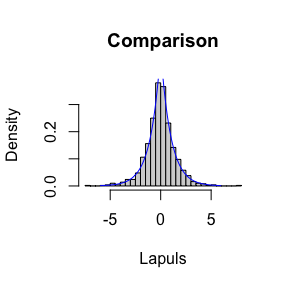

```r
ranmd <- runif(1000) #生成 1000 个介于 0 到 1 之间的均匀分布的随机数

Lapuls <- sign(ranmd - 0.5) * log( 1 - 2 * abs(ranmd - 0.5)) # 拉普拉斯分布的逆变换

# 绘制生成样本的直方图
hist(Lapuls, breaks = 30, freq = FALSE, main = "Comparison")

# 叠加目标概率密度函数
x <- seq(-6, 6, length.out = 120)
fx <- (exp(-abs(x))) / 2
lines(x, fx, col = "blue")
```

### 3. 习题 3.7

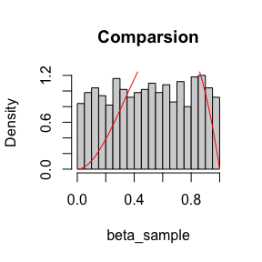

```r
#使用acceptance-rejection method 定义功能函数

AR_m <- function(n, a, b) {
    sample <- numeric(n)
    count <- 1
  while(count <= n) {
    x<- runif(1)
    y <- runif(1, min = 0, max = dbeta(x, a, b))
    if(y <= dbeta(x, a, b)) {
      sample[count] <- x
      count <- count + 1
    }
  }
  return(sample)
}

#采用理论Beta(3,2)生成1000个随机样本
beta_sample <- AR_m(1000, 3, 2)

# 绘制生成样本的直方图
hist(beta_sample, breaks = 29, freq = FALSE, main = "Comparsion")

# 叠加理论密度函数
x <- seq(0, 1, length.out = 100)
f_beta <- dbeta(x, 3, 2)
lines(x, f_beta, col = "red")
```

### 4. 习题 3.9

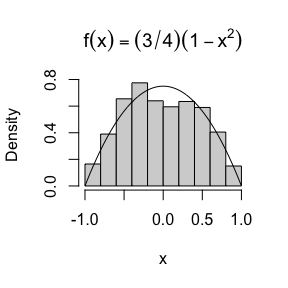

```r
#采用beta生成随机数拟合
y <- rbeta(1000,2,2)
x <- 2*y-1

# 绘制直方图
hist(x, prob = TRUE, main = expression(f(x)==(3/4)(1-x^2)))
m <- seq(-1, 1, 0.01) #将结果进行拟合
lines(m, (3/4)*(1-m^2))
```

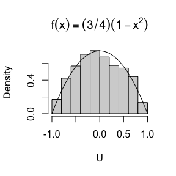

```r
# 定义变量和空向量

v1 <- 790
i <- 0
U <- numeric(v1)

# 生成随机数并进行拟合
for (i in 1:v1) {
  U1 <- runif(v1,-1,1)
  U2 <- runif(v1,-1,1)
  U3 <- runif(v1,-1,1)
  if(abs(U3[i]) >= abs(U2[i]) && abs(U3[i]) >= abs(U1[i])){
    U[i] <- U2[i]}
  else {
     U[i] <- U3[i]
   }
}

# 绘制直方图和拟合结果
hist(U, prob = TRUE, main = expression(f(x)==(3/4)(1-x^2)))
V <- seq(-1, 1, 0.01)
lines(V, (3/4)*(1-V^2))
```

### 4. 习题 3.10

$$根据函数分布特点，对u分区间讨论，计算其累计分布函数$$
$$\ 当-1\le u\le 0时，F(U\le u )=F_{1}+F_{2}\$$
$$其中F_{1}=\int_{-1}^{u} \int_{-\left|u_{3}\right|}^{u}
\int_{-\left|u_{3}\right|}^{\left|u_{3}\right|} f\left(u_{1}\right)
f\left(u_{2}\right) f\left(u_{3}\right) d u_{1} d u_{2} d u_{3}
+\int_{-u}^{1} \int_{-\left|u_{3}\right|}^{u}
\int_{-\left|u_{3}\right|}^{\left|u_{3}\right|} f\left(u_{1}\right)
f\left(u_{2}\right) f\left(u_{3}\right) d u_{1} d u_{2} d u_{3}\
=-\frac{u^{3}}{12}+\frac{u}{4}+\frac{1}{6}\$$
$$由对称性可得
F_2=4\int_{-1}^{u} \int_{|u_3|}^{1} f\left(u_{1}\right)
f\left(u_{3}\right) d u_{1} d u_{3}\ -2[\int_{-1}^{u} \int_{-1}^{u_3}
\int_{-1}^{u_3} f\left(u_{1}\right) f\left(u_{2}\right)
f\left(u_{3}\right) d u_{1} d u_{2} d u_{3}+\int_{-1}^{u}
\int_{|u_3|}^{1} \int_{|u_3|}^{1} f\left(u_{1}\right)
f\left(u_{2}\right) f\left(u_{3}\right) d u_{1} d u_{2} d u_{3}]\
=-\frac{u^{3}}{6}+\frac{u}{2}+\frac{1}{3}\$$

$$即F_2=-\frac{u^{3}}{6}+\frac{u}{2}+\frac{1}{3}\$$
$$所以，当-1\le u\le 0时，F(U\le u
)=F_{1}+F_{2}=-\frac{u^{3}}{12}+\frac{u}{4}+\frac{1}{6}-\frac{u^{3}}{6}+\frac{u}{2}+\frac{1}{3}\
=-\frac{u^{3}}{4}+\frac{3 u}{4}+\frac{1}{2}\$$

$$同理，当0 \le u\le 1时，可得\ F(U\le u
)=F_{1}+F_{2}=-\frac{u^{3}}{4}+\frac{3 u}{4}+\frac{1}{2}\$$

$$即 f(u)= \frac{3}{4}(1-u^2)\ (-1 \le u\le 1)$$

$$所以f(u)=f_{e}(x),原命题得证$$

### HW2 2023/09/25

### Question

1,Proof that what value ρ = l/d should take to minimize the asymptotic variance of πˆ? (m ∼ B(n, p), using δ method)

2,Take three different values of ρ (0 ≤ ρ ≤ 1, including ρmin) and use Monte Carlo simulation to verify your answer. (n = 1e6, Number of repeated simulations K = 100)

2,Exercises 5.6, 5.7 (pages 149-151, Statistical Computing with R).

5.6. In Example 5.7 the control variate approach was illustrated for Monte Carlo integration of
$$θ = \int_{0}^{1} e^x dx\$$
Now consider the antithetic variate approach. Compute Cov(e^U, e^1−U) and V ar(e^U + e^1−U), where U ∼ Uniform(0,1). What is the percent reduction in variance of θˆ that can be achieved using antithetic variates (compared with simple MC)?

5.7. Refer to Exercise 5.6. Use a Monte Carlo simulation to estimate θ by the antithetic variate approach and by the simple Monte Carlo method. Compute an empirical estimate of the percent reduction in variance using the antithetic variate. Compare the result with the theoretical value from Exercise 5.6.

### Answer

### 1. 证明求解最小ρ

$$由题意有 ρ = \frac{l}{d} , π = \frac{2l}{dp}$$
$$其中, m ∼ B(n, p), 即有 p = \frac{m}{n}, Var(m) = np(1-p)$$
$$根据 δ 方法, π的渐进方差 var(π) 可表示为$$
$$var(π) = (\frac{∂π}{∂p})^2*var(p)=(\frac{∂π}{∂p})^2*\frac{var(m)}{n^2}$$
$$其中, \frac{∂π}{∂p}=-\frac{2l}{dp^2}, Var(m) = np(1-p)$$
$$代入化简可得,var(π) = \frac{4l^2(1-p)}{nd^2p^3}$$
$$又 π = \frac{2l}{dp} ,ρ = \frac{l}{d} ,可得 p = \frac{2ρ}{π}，并带入上式$$
$$即有,var(π) = \frac{π^3}{2nρ}- \frac{π}{n}$$
$$对等式两边ρ 进行求导,有 \frac{∂var(π)}{∂ρ } = -\frac{π^3}{2nρ^2}，
其明显恒小于0，又0 ≤ ρ ≤ 1$$
$$因此， 解得令π的渐进方差 var(π)最小的ρ_{min}取值为1$$

### 2. 比较三种不同ρ取值对π的方差的影响

```r
# 构建函数，即用MC算法模型计算π的方差

var_pi_MC <- function(ρ){

# 设置参数
n <- 1e6  # 模拟实验的总次数
k <- 100  # 模拟次数

# 创建空向量存储每次模拟的结果
pi_ <- numeric(k)

# 模拟计算圆周率
for (i in 1:k) {
  m <- rbinom(1, n, 2*ρ/pi)  # 生成服从二项分布的随机数
  pi_[i] <- 2*ρ*n/m  # 计算圆周率的模拟值
}

# 计算方差
var_pi <- var(pi_)
var_pi

}

# 比较三种不同ρ取值

var_pi_MC(ρ=1)
```

```
## [1] 5.029201e-06
```

```r
var_pi_MC(ρ=0.8)
```

```
## [1] 1.0142e-05
```

```r
var_pi_MC(ρ=0.5)
```

```
## [1] 2.539532e-05
```

$$明显，MC算法中，ρ= 1时，π的方差最小$$

### 5.6.antithetic variate 法对比 simple MC 法

```r
# 采用antithetic variate 法 计算对应协方差和方差

# 设置参数
n <- 1e6/2

# antithetic variate 法构建变量
U_1 <- runif(n, min=0, max=1)
U_2 <- rep(1, n) - U_1

expU = (exp(U_1)+exp(U_2))/2
exp1_U = (exp(1-U_1)+exp(1-U_2))/2
# 计算对应协方差和方差
Cov_av <- cov(expU,exp1_U)
Var_av <- var(expU+exp1_U)

# 采用MC法计算方差
m <- 1e6
U_ <- runif(m, min=0, max=1)
var_mc = var(exp(U_))/m

# 采用antithetic variate 法计算方差
var_av = var(expU)/n

reduction_var = (var_mc - var_av) / var_mc * 100
#  打印结果
print(paste("Cov using antithetic variate:", Cov_av))
```

```
## [1] "Cov using antithetic variate: 0.00390860590965218"
```

```r
print(paste("Var using antithetic variate:", Var_av))
```

```
## [1] "Var using antithetic variate: 0.0156344236386087"
```

```r
print(paste("Percentage reduction in variance:", reduction_var, "%"))
```

```
## [1] "Percentage reduction in variance: 96.7708770180613 %"
```

### 5.7.antithetic variate 法对比 simple MC 法

```r
# 采用MC法估计
m <- 1e6
U_ <- runif(m, min=0, max=1)
# 计算估计量及其方差
Ex_mc = mean(exp(U_))
var_mc = var(exp(U_))/m

# antithetic variate 法估计

# 设置参数
n <- 1e6/2
# antithetic variate 法构建变量expU
U_1 <- runif(n, min=0, max=1)
U_2 <- rep(1, n) - U_1

expU = (exp(U_1)+exp(U_2))/2

# 采用antithetic variate 法计算方差
Ex_av = mean(expU)
var_av = var(expU)/n

reduction_var = (var_mc - var_av) / var_mc * 100

print(paste("estimation using simple MC:", Ex_mc))
```

```
## [1] "estimation using simple MC: 1.7184048997718"
```

```r
print(paste("estimation using antithetic variate:",Ex_av))
```

```
## [1] "estimation using antithetic variate: 1.71810915636747"
```

```r
print(paste("经计算，对比simple MC法，采用antithetic variate法的估计量方差降低百分比为", reduction_var, "%"))
```

```
## [1] "经计算，对比simple MC法，采用antithetic variate法的估计量方差降低百分比为 96.7653279138689 %"
```

### HW3 2023/10/09

### Question

$$Var(θ^M) = \frac{1}{MK}\sum_{i=1}^k σ_i^2 +\frac{1}{M} Var(θ_I) =
Var(θ^S)+ \frac{1}{M} Var(θ_I),where\ θ_i
=E(g(U)|I=i), \ σ_i^2 =\ Var(g(U)|I=i)$$
$$and\ I \ takes\ unifrom\ distribution\ over\{1,..,k\}.\ Proof\ that\ if\
g\ is\ a\ continuous\ function over(a,b),$$
$$then\ \frac{Var(θ^S)}{Var(θ^M)}\ \to\ 0 \ as\ b_i - a_i\ \to0\ for\ all\
i=1,..,k$$
2.

• Exercises 5.13, 5.14, 5.15 (pages 149-151, Statistical Computing with R).

• Exercises 6.5, 6.A (pages 180-181, Statistical Computing with R)

5.13.

Find two importance functions f1 and f2 that are supported on (1, ∞) and are ‘close’ to
$$g(x)\ =\ \frac{x^2}{\sqrt{2\pi}}\ e^{-\frac{x^2}{2}},\ x>1.$$
Which of your two importance functions should produce the smaller variance in estimating
$$\int_{1}^{∞} \frac{x^2}{\sqrt{2\pi}}\ e^{-\frac{x^2}{2}}\ d x$$
by importance sampling? Explain.

5.14.

Obtain a Monte Carlo estimate of
$$\int_{1}^{∞} \frac{x^2}{\sqrt{2\pi}}\ e^{-\frac{x^2}{2}}\ d x$$
by importance sampling.

5.15

Obtain the stratified importance sampling estimate in Example 5.13 and compare it with the result of Example 5.10.

6.5

Suppose a 95% symmetric t-interval is applied to estimate a mean, but the sample data are non-normal. Then the probability that the confidence interval covers the mean is not necessarily equal to 0.95. Use a Monte Carlo experiment to estimate the coverage probability of the t-interval for random samples of χ2(2) data with sample size n = 20. Compare your t-interval results with the simulation results in Example 6.4. (The t-interval should be more robust to departures from normality than the interval for variance.)

6.A

Use Monte Carlo simulation to investigate whether the empirical Type I error rate of the t-test is approximately equal to the nominal significance level α, when the sampled population is non-normal. The t-test is robust to mild departures from normality. Discuss the simulation results for the cases where the sampled population is (i) χ2(1), (ii) Uniform(0,2), and (iii) Exponential(rate=1). In each case, test H0 : µ = µ0 vs H0 : µ ∕= µ0, where µ0 is the mean of χ2(1), Uniform(0,2), and Exponential(1), respectively.

### Answer

### 1. Proof the formula is close to zero

由于 $g$ 是连续的函数，在每个子区间 $(a_i, b_i)$ 上 $g$ 的值都将趋近于一个常数（假设为 $c$）。这意味着在每个子区间上 $g$ 的值的方差 $Var(g(U)|I=i) = σ_i^2$ 将趋近于0，因为所有的值都趋近于一个常数。由于 $Var(θ^S) = \frac{1}{Mk} \sum_{i=1}^k σ_i^2$，所以所有的 $σ_i^2 \to 0$ 也将导致 $Var(θ^S) \to 0$。

同时，因为 $I$ 在 ${1,2, ... ,k}$ 上取均匀分布， 所以对于所有的 $b_i - a_i \to 0$，我们有

$$\frac{1}{MK}\sum_{i=1}^k σ_i^2 \to 0$$
而
$$Var(θ^M) = \frac{1}{MK}\sum_{i=1}^k σ_i^2 +\frac{1}{M} Var(θ_I).$$

于是我们有

$$\frac{Var(θ^S)}{Var(θ^M)} = \frac{\frac{1}{MK}\sum_{i=1}^k
σ_i^2}{\frac{1}{MK}\sum_{i=1}^k σ_i^2 +\frac{1}{M} Var(θ_I).}
=\frac{1}{1 +\frac{Var(θ_I).}{\frac{1}{K}\sum_{i=1}^k σ_i^2} }$$
$$其中， Var(θ_I)>0,\ \frac{1}{K}\sum_{i=1}^k σ_i^2 \to
0,即\frac{Var(θ_I).}{\frac{1}{K}\sum_{i=1}^k σ_i^2}\to∞$$
所以
$$\frac{Var(θ^S)}{Var(θ^M)} =\frac{1}{1
+\frac{Var(θ_I).}{\frac{1}{K}\sum_{i=1}^k σ_i^2} } \to\ 0$$
对于所有 i 属于{1, 2, …, k}。这完成了证明。

### 5.13. Find two importance functions f1 and f2

```r
# 定义g(x)，f1(x), f2(x)
g <- function(x) {
  (x^2) / sqrt(2*pi) * exp(-x^2/2)
}

# 用伽马分布定义重要性抽样函数f1(x)
f1 <- function(x) {
  dgamma(x, shape = 2.5, rate = 1.35)
}

# 用正态分布定义重要性函数f2(x)
f2 <- function(x) {
  dnorm(x, mean = 1.4, sd = 1.15)
}


# 从重要性抽样分布生成样本
n <- 100000      # Number of samples
x1 <- rgamma(n, shape = 2.5, rate = 1.35)
x1 <- x1[x1 > 1]    # Keep only samples greater than 1

# 用f1计算重要性抽样估计
estimate1 <- mean(g(x1)/f1(x1))
variance1 <- var(g(x1)/f1(x1))

# 使用f2生产随机样本
x2 <- rnorm(n, mean = 1.4, sd = 1.15)
x2 <- x2[x2 > 1]


# 用f2计算重要性抽样估计
estimate2 <- mean(g(x2)/f2(x2))
variance2 <- var(g(x2)/f2(x2))


cat("使用f1的重要性抽样估计: ", estimate1, " Variance: ", variance1, "\n")
```

```
## 使用f1的重要性抽样估计:  0.5373048  Variance:  0.06296884
```

```r
cat("使用f2的重要性抽样估计: ", estimate2, " Variance: ", variance2)
```

```
## 使用f2的重要性抽样估计:  0.6286129  Variance:  0.05262537
```

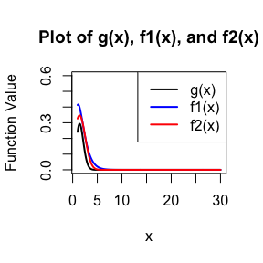

```r
# 为绘图创建x值
x <- seq(1, 30, by = 0.1)

# 绘制 g(x), f1(x), and f2(x)
plot(x, g(x), type = "l", lwd = 2, ylim = c(0, 0.6),
     main = "Plot of g(x), f1(x), and f2(x)",
     xlab = "x", ylab = "Function Value")

lines(x, f1(x), col = "blue", lwd = 2)
lines(x, f2(x), col = "red", lwd = 2)

# 添加图例
legend("topright", legend = c("g(x)", "f1(x)", "f2(x)"), lwd = 2, col = c("black", "blue", "red"))
```

可以发现采用正态分布函数f2 作为重要性函数，其估计量的方差更小，即评估效果更好

### 5.14 MC estimate by importance sampling.

```r
# 定义g函数
g <- function(x) {
  (x^2) / sqrt(2*pi) * exp(-x^2/2)
}

#用正态分布定义重要性函数f(x)
f <- function(x) {
  dnorm(x, mean = 1.4, sd = 1.15)
}

# 用正态分布生产随机样本
n <- 1e5
x <- rnorm(n, mean = 1.4, sd = 1.15)
x <- x[x > 1]


# 计算重要性抽样估计值
estimate <- mean(g(x) / f(x))

# 输出结果
cat("采用重要性抽样的蒙特卡罗估计:", estimate)
```

```
## 采用重要性抽样的蒙特卡罗估计: 0.6318166
```

### 5.15 the stratified importance sampling estimate

```r
# 定义区间数
m <- 5

# 模拟次数
N <- 1e5

# 重要性函数
f3 <- function(x) exp(-x) / (1 - exp(-1))

# 原始密度函数
g  <- function(x) exp(-x) / (1 + x^2)

# 开始变量
theta.hat <- 0
se <- 0

# 分层重要采样法
for (j in 0:(m - 1)) {

  # 第j个区间的下界和上界
  lower <- j / m
  upper <- (j + 1) / m

  # 重复实验
  for (i in 1:N) {
    # 生成随机样本
    u <- runif(1, lower, upper)

  # 更新均值和标准差
    theta.hat <- theta.hat + g(u) / f3(u)
    se <- se + (g(u) / f3(u))^2
  }
}

# 完成估算
theta.hat <- theta.hat / (m * N)
se <- sqrt((se / (m * N) - theta.hat^2) / (m * N - 1))

print(paste('估计值θ：', theta.hat))
```

```
## [1] "估计值θ： 0.496452862474818"
```

```r
print(paste('估计值的标准差：', se))
```

```
## [1] "估计值的标准差： 0.000143694534537369"
```

对比例5.10的结果来说，采用分层重要抽样法能得到更准确的结果，同时标准差更小

### 6.5 Estimate the coverage probability of the t-interval

```r
set.seed(123)

# 模拟次数
N <- 5000

# 样本大小
n <- 20

# 卡方分布的自由度
df <- 2

# 卡方分布均值
true_mean <- df

# 初始化计数值
coverage_count <- 0

# Monte Carlo simulation
for (i in 1:N) {
  # 生产卡方分布随机数
  sample <- rchisq(n, df)

  # 估计t区间
  t_interval <- t.test(sample)$conf.int

  # 检查真实均值是否在区间内
  if (true_mean >= t_interval[1] && true_mean <= t_interval[2]) {
    coverage_count <- coverage_count + 1
  }
}

# 估计覆盖概率
coverage_P<- coverage_count / N

print(paste('估计t区间的覆盖概率为', coverage_P))
```

```
## [1] "估计t区间的覆盖概率为 0.9242"
```

### 6.A

```r
set.seed(123)

# 定义参数
alpha <- 0.05
n <- 100
num_sims <- 5000

# 计算双侧t检验的临界值
t_critical <- qt(1 - alpha/2, df = n - 1)

# 定义总体分布函数和对应的均值
chisq_dist <- function(n) {
  rchisq(n, df = 1)
}

unif_dist <- function(n) {
  runif(n, 0, 2)
}

exp_dist <- function(n) {
  rexp(n, rate = 1)
}

distributions <- list(chisq = list(f = chisq_dist, mean = 1),
                      unif = list(f = unif_dist, mean = 1),
                      exp = list(f = exp_dist, mean = 1))

# 对每种分布进行模拟
results <- sapply(names(distributions), function(dist) {

  # 获取总体分布的函数和均值
  rdist <- distributions[[dist]]$f
  mu0 <- distributions[[dist]]$mean

  # 对于每次模拟，生成样本并进行t检验
  rejected <- replicate(num_sims, {
    x <- rdist(n)
    t_test_result <- t.test(x, mu = mu0)
    t_test_result$p.value < alpha/2 || t_test_result$p.value > 1 - alpha/2
  })

  # 计算实际的类型I错误率
  error_rate <- mean(rejected)

  # 返回实际的类型I错误率
  return(error_rate)
})

# 打印结果
names(results) <- names(distributions)
print(results)
```

```
##  chisq   unif    exp
## 0.0644 0.0494 0.0574
```

### HW4 2023/10/16

### Question

$1. \quad$考虑 m=1000个假设，其中前95%个原假设或后5%个对立假设成立。在原假设之下，p-值服从U（0，1）分布，在对立假设之下，p-值服从Beta(0.1,1)分布。应用Bonferroni校正和B-H校正应用与生成的m个p值（孤立）（应用P.adjust）,得到校正后的P值，与x=0.1比较确定是否拒绝原假设，基于M=1000次模拟，估计FWER，FDR，TDR输出到表格

$2.\quad$Suppose the population has the exponential distribution with rate λ, then the MLE of λ is λˆ = 1/X¯ , where X¯ is the sample mean. It can be derived that the expectation of λˆ is λn/(n − 1),so that the estimation bias is λ/(n − 1). The standard error λˆ is λn/[(n − 1)√n − 2]. Conduct a simulation study to verify the performance of the bootstrap method.

The true value of λ = 2. The sample size n = 5, 10, 20. The number of bootstrap replicates B = 1000. The simulations are repeated for m = 1000 times.

Compare the mean bootstrap bias and bootstrap standard error with the theoretical ones. Comment on the result.

Exercises 7.3 (pages 212, Statistical Computing with R).

$7.3 \quad$ Obtain a bootstrap t confidence interval estimate for the correlation statistic in Example 7.2 (law data in bootstrap).

### Answer

### 1.

```r
# 定义一些参数
m = 1000
M = 1000

fwer = tpr = fdr = matrix(NA, nrow = 2, ncol = M)

# 进行 M次模拟
for (j in 1:M) {

  #生成 p值
  pvalue = c(runif(950), rbeta(50, 0.1, 1))

  #处理Bonferroni方法
  pvalue.Bonf = p.adjust(pvalue, method = "bonferroni")
  #确定是否拒绝原假设
  reject.Bonf = pvalue.Bonf < 0.1

  #计算 FWER， FDR， TDR
  fwer[1, j] = any(reject.Bonf[1:950])
  fdr[1, j] = sum(reject.Bonf[1:950]) / sum(reject.Bonf)
  tpr[1,j] =  sum(reject.Bonf[951:m]) / 50

  #处理BH方法
  pvalue.BH = p.adjust(pvalue, method = "BH")
  #确定是否拒绝原假设
  reject.BH = pvalue.BH < 0.1

  #计算 FWER， FDR， TDR
  fwer[2, j] = any(reject.BH[1:950])
  fdr[2, j] = sum(reject.BH[1:950]) / sum(reject.BH)
  tpr[2,j] =  sum(reject.BH[951:m]) / 50
}

# 输出结果矩阵
result = matrix(c(rowMeans(fwer, na.rm = TRUE), rowMeans(fdr, na.rm = TRUE), rowMeans(tpr, na.rm = TRUE)), nrow = 2)
colnames(result) <- c("FWER", "FDR", "TPR")
rownames(result) <- c("Bonf", "B-H")
result
```

```
##       FWER         FDR     TPR
## Bonf 0.093 0.004989825 0.39110
## B-H  0.931 0.094765891 0.55726
```

### 2.

```r
# 设置参数
lambda <- 2
sample_sizes <- c(5, 10, 20)
B <- 1000
m <- 1000

# 创建存储结果的向量
mean_bias <- numeric(length(sample_sizes))
bootstrap_bias <- numeric(length(sample_sizes))
theoretical_se <- numeric(length(sample_sizes))
bootstrap_se <- numeric(length(sample_sizes))
theoretical_bias <- numeric(length(sample_sizes))

# 循环进行仿真
for (i in 1:length(sample_sizes)) {
  n <- sample_sizes[i]
  bias <- numeric(m)
  se <- numeric(m)

  for (j in 1:m) {
    # 生成样本数据
    x <- rexp(n, rate = lambda)
    x_mean <- mean(x)

    # 计算极大似然估计
    lambda_hat <- 1/x_mean

    # 生成bootstrap样本数据
    bootstrap_samples <- replicate(B, {
      resample <- sample(x, replace = TRUE)
      1/mean(resample) })

    # 计算偏差
    bias[j] <-mean(bootstrap_samples)-lambda_hat
    # 计算bootstrap估计的标准误差
    se[j] <- sd(bootstrap_samples)
  }

  # 计算平均偏差和标准误
  theoretical_bias[i] = lambda/(n-1)
  mean_bias[i] <- mean(bias)
  theoretical_se[i] <- lambda*n/((n-1)*sqrt(n-2))
  bootstrap_se[i] <- mean(se)
}

# 打印结果
results <- data.frame(
  n = sample_sizes,
  Bootstrap_Bias = mean_bias,
  Theoretical_Bias = theoretical_bias,
  Bootstrap_SE = bootstrap_se,
  Theoretical_SE = theoretical_se
)
print(results)
```

```
##    n Bootstrap_Bias Theoretical_Bias Bootstrap_SE Theoretical_SE
## 1  5      0.5950116        0.5000000    2.6563014      1.4433757
## 2 10      0.2197729        0.2222222    0.8277460      0.7856742
## 3 20      0.1035766        0.1052632    0.4996537      0.4962153
```

```r
print("可以看出，采用Bootstrap重采样方法能良好地估计偏差和标准误差，当n值越大时，其估计值与理论值更接近")
```

```
## [1] "可以看出，采用Bootstrap重采样方法能良好地估计偏差和标准误差，当n值越大时，其估计值与理论值更接近"
```

### 7.3

```r
# 从bootstrap库中导入law数据
data(law, package = "bootstrap")

#定义函数
boot.t.ci <-
function(x, B, R, level = .95, statistic){
  #计算bootstrap t置信区间
  x <- as.matrix(x); n <- nrow(x)
  stat <- numeric(B); se <- numeric(B)
    boot.se <- function(x, R, f) {
    #定义局部函数估计statistich的标准误差
    x <- as.matrix(x); m <- nrow(x)
    th <- replicate(R, expr = {
        i <- sample(1:m, size = m, replace = TRUE)
        f(x[i, ])
        })
        return(sd(th))
    }
  for (b in 1:B) {
    j <- sample(1:n, size = n, replace = TRUE)
    y <- x[j, ]
    stat[b] <- statistic(y)
    se[b] <- boot.se(y, R = R, f = statistic)
  }
  stat0 <- statistic(x)
  t.stats <- (stat - stat0) / se
  se0 <- sd(stat)
  alpha <- 1 - level
  Qt <- quantile(t.stats, c(alpha/2, 1-alpha/2), type = 1)
  names(Qt) <- rev(names(Qt))
  CI <- rev(stat0 - Qt * se0)
}

#估计bootstrap t置信区间
ci <- boot.t.ci(law, statistic = function(x, i){cor(x[i,1], x[i,2])}, B=2000, R=200)

# 打印结果
cat("bootstrap t置信区间估计：",ci)
```

```
## bootstrap t置信区间估计： -0.2676714 1.00656
```

### HW5 2023/10/23

### Question

Exercises 7.5 7.8 7.11 (pages 212-213, Statistical Computing with R).

7.5 Refer to Exercise 7.4. Compute 95% bootstrap confidence intervals for the mean time between failures 1/λ by the standard normal, basic, percentile, and BCa methods. Compare the intervals and explain why they may differ.

7.8 Refer to Exercise 7.7. Obtain the jackknife estimates of bias and standard error of θˆ.

7.11 In Example 7.18, leave-one-out (n-fold) cross validation was used to select the best fitting model. Use leave-two-out cross validation to compare the models.

### Answer

### 7.5.

```r
# 加载所需包
library(boot)

# 定义数据
times <- c(3, 5, 7, 18, 43, 85, 91, 98, 100, 130, 230, 487)

# 进行bootstrap计算置信区间（样本均值是 1 / λ 的无偏估计）
boot_results <- boot(times, statistic = function(data,index)mean(data[index]), R = 2000)
boot.ci(boot_results, type = c("norm", "basic", "perc", "bca"))
```

```
## BOOTSTRAP CONFIDENCE INTERVAL CALCULATIONS
## Based on 2000 bootstrap replicates
##
## CALL :
## boot.ci(boot.out = boot_results, type = c("norm", "basic", "perc",
##     "bca"))
##
## Intervals :
## Level      Normal              Basic
## 95%   ( 33.3, 183.2 )   ( 25.2, 170.9 )
##
## Level     Percentile            BCa
## 95%   ( 45.3, 191.0 )   ( 57.0, 233.8 )
## Calculations and Intervals on Original Scale
## Some BCa intervals may be unstable
```

每种置信区间方法都可能产生不同的结果。这是因为标准正态方法假设样本均值的分布服从正态分布，基本方法假设bootstrap估计的分布近似对称，百分位方法基于bootstrap估计的分布百分位数，而BCa方法考虑了bootstrap估计的分布偏差和偏斜度,

### 7.8.

```r
library(bootstrap)

# 计算相关系数
b.cor <- function(x, i) {
  cor(x[i, 1], x[i, 2])
}

# 计算特征值比例
calculate_theta <- function(x) {
  lambdas <- eigen(x)$values
  sumlam <- sum(lambdas)
  theta <- lambdas[1] / sumlam
  return(theta)
}

# Bootstrap方法估计参数偏差和标准误差
bootstrap_estimate <- function(x, B) {
  lambdas <- eigen(x)$values
  sumlam <- sum(lambdas)
  theta <- lambdas[1] / sumlam
  y <- lambdas / sumlam

  thetastar <- numeric(B)

  for (b in 1:B) {
    xstar <- sample(y, replace = TRUE)
    thetastar[b] <- mean(xstar)
  }

  bias <- mean(thetastar) - theta
  se <- sd(thetastar)

  result <- c(Bias.boot = bias, SE.boot = se)
  return(round(result, 3))
}

# 测试代码
x <- cov(scor, scor)
B <- 10000

bootstrap_estimate(x, B)
```

```
## Bias.boot   SE.boot
##    -0.419     0.096
```

# 7.11

```r
# 加载数据
library(DAAG);data(ironslag)
# 获取磁力观测值数量
n <- length(ironslag$magnetic)

# 初始化存储拟合误差的矩阵
mse1 <- mse2 <- mse3 <- mse4 <- matrix(0, n, n)

# 嵌套循环，遍历磁力观测值的组合
for (i in 1:(n-1)) {
  for (j in (i+1):n) {
    y <- ironslag$magnetic[c(-i, -j)]  # 创建新的磁力向量，排除当前的i和j观测值
    x <- ironslag$chemical[c(-i, -j)]  # 创建新的化学成分向量，排除当前的i和j观测值

    # 拟合回归模型J1，使用lm()函数，y作为因变量，x作为自变量
    J1 <- lm(y ~ x)
    yhat1 <- J1$coef[1] + J1$coef[2] * ironslag$chemical[c(i, j)]  # 计算预测值（yhat1）
    mse1[i, j] <- mean((ironslag$magnetic[c(i, j)] - yhat1)^2)  # 计算平方误差，并存储在相应的e1矩阵位置上

    # 类似地，拟合回归模型J2，包括二次项
    J2 <- lm(y ~ x + I(x^2))
    yhat2 <- J2$coef[1] + J2$coef[2] * ironslag$chemical[c(i, j)] + J2$coef[3] * ironslag$chemical[c(i, j)]^2
    mse2[i, j] <- mean((ironslag$magnetic[c(i, j)] - yhat2)^2)

    # 拟合回归模型J3，对磁力取对数
    J3 <- lm(log(y) ~ x)
    logyhat3 <- J3$coef[1] + J3$coef[2] * ironslag$chemical[c(i, j)]
    yhat3 <- exp(logyhat3)
    mse3[i, j] <- mean((ironslag$magnetic[c(i, j)] - yhat3)^2)

    # 拟合回归模型J4，对磁力和化学成分都取对数
    J4 <- lm(log(y) ~ log(x))
    logyhat4 <- J4$coef[1] + J4$coef[2] * log(ironslag$chemical[c(i, j)])
    yhat4 <- exp(logyhat4)
    mse4[i, j] <- mean((ironslag$magnetic[c(i, j)] - yhat4)^2)
  }
}

# 计算均方误差的均值
result <- c(L1_MSE = sum(mse1)/choose(n, 2), L2_MSE = sum(mse2)/choose(n, 2), L3_MSE = sum(mse3)/choose(n, 2), L4_MSE = sum(mse4)/choose(n, 2))
# 返回包含四个模型的均方误差的向量
result
```

```
##   L1_MSE   L2_MSE   L3_MSE   L4_MSE
## 19.57227 17.87018 18.45491 20.46718
```

显然，模型2 的均方误差最小，根据预测误差准则，模型2即二次模型最适合该数据

### HW6 2023/10/30

### Question

$1. \quad$Proof the Stationarity of Metropolis-Hastings sampler Algorithm in continuous situation.

$\ • \$Exercises 8.1 8.3 (pages 242-243, Statistical Computing with R).

$8.1. \quad$ Implement the two-sample Cram´er-von Mises test for equal distributions as a permutation test. Apply the test to the data in Examples 8.1 and 8.2.

$8.3. \quad$The Count 5 test for equal variances in Section 6.4 is based on the maximum number of extreme points. Example 6.15 shows that the Count 5 criterion is not applicable for unequal sample sizes. Implement a permutation test for equal variance based on the maximum number of extreme points that applies when sample sizes are not necessarily equal.

### 1.

$由题设可知，目标分布：f(x).提议分布：g(r|s),接受概率:a(s,r)\ = \ min\{\frac{f(r)g(s|r)}{f(s)g(r|s)},1\}$ $转移核函数: K(r,s) = a(r,s)g(s|r)\ +\ I(s=r)[1-\int_{a}^{} (r,s)g(s|r)\ ds].$

$$要证明在连续情况下，MH算法中的细致平稳条件，即K(s,r)f(s) = K(r,s)f(r)$$

$(1)\ \ 当 r = s 时，显然，K(s,r)f(s) = K(r,s)f(r)成立$

$(2)\ \ 当 r ≠ s 时，I(s=r)=0,$

$有，\ \ \ f(r)K(r,s) = f(r)a(r,s)g(s|r)\ =\ f(r)g(s|r)\ min\{\frac{f(s)g(r|s)}{f(r)g(s|r)},1\}$

$同理可得，f(s)K(s,r) = f(s)a(s,r)g(r|s)\ =\ f(s)g(r|s)\ min\{\frac{f(r)g(s|r)}{f(s)g(r|s)},1\}$

$如果 f(s)g(r|s) ≥ f(r)g(s|r)，那么 min\{\frac{f(s)g(r|s)}{f(r)g(s|r)},1\} =\ 1,则，f(r)K(r,s) =\ f(r)g(s|r)$

$同时，f(s)K(s,r) = \ f(s)g(r|s) *\frac{f(r)g(s|r)}{f(s)g(r|s)} = \ f(r)g(s|r)$

$故当 f(s)g(r|s) ≥ f(r)g(s|r)\ 时，K(s,r)f(s) = K(r,s)f(r)成立$

$同理，f(s)g(r|s) < f(r)g(s|r)\ 时，K(s,r)f(s) = K(r,s)f(r)也成立$
$$综上，K(s,r)f(s) = K(r,s)f(r)$$

### 8.1

```r
# 定义Cramér-von Mises统计量函数
cvm_test <- function(X, Y) {
    group <- c(rep(1, length(X)), rep(2, length(Y)))
    data <- c(X, Y)
    n <- length(data)
    ranks <- rank(data)
    U1 <- sum(ranks[group == 1])
    n1 <- length(X)
    n2 <- length(Y)
    T <- (U1 - n1*(n1+1)/2)^2 / (n1*n2)  # Cramér-von Mises 统计量
    return(T)
}

# 定义置换测试函数
permutation_test <- function(x, y, num_permutations = 10000, test_fn) {
    observed_value <- test_fn(x, y)
    pooled <- c(x, y)
    extreme_count <- 0
    for(i in seq_len(num_permutations)){
        permuted <- sample(pooled, length(pooled))
        perm_x <- permuted[seq_len(length(x))]
        perm_y <- permuted[-seq_len(length(x))]
        if(test_fn(perm_x, perm_y) >= observed_value){
            extreme_count <- extreme_count + 1
        }
    }
    return(extreme_count / num_permutations)  # p值
}
# 定义X和Y样本
X <- c(158, 171, 193, 199, 230, 243, 248, 248, 250, 267, 271, 316, 327, 329)
Y <- c(141, 148, 169, 181, 203, 213, 229, 244, 257, 260, 271, 309)

# 计算
p_value <- permutation_test(X, Y, 10000, cvm_test)
print(p_value)
```

```
## [1] 0.114
```

### 8.3

```r
set.seed(2023) # 设置随机种子以确保结果可重复

count5test <- function(x, y) {
  # 对x和y进行中心化
  X <- x - mean(x)
  Y <- y - mean(y)

  # 计算权重
  w <- round(10 * (length(x)/(length(x) + length(y))))

  # 计算超出边界值的数量
  outx <- sum(X > max(Y)) + sum(X < min(Y))
  outy <- sum(Y > max(X)) + sum(Y < min(X))

  # 如果最小的数量超过权重或者最大的数量超过10减去权重，则拒绝原假设（返回1），否则保留原假设（返回0）
  return(as.integer(min(c(outx, outy)) > w || max(c(outx, outy)) > (10 - w)))
}

R <- 10000 # 模拟实验的重复次数

n1 <- 20 # 第一组样本的大小
n2 <- 30 # 第二组样本的大小

weight <- round(10 * (n1/(n1 + n2))) # 计算权重

# 从正态分布生成第一组样本x
x <- rnorm(n1, 0, 1)
# 从正态分布生成第二组样本y
y <- rnorm(n2, 0, 1)

# 将x和y合并为一个总体样本z
z <- c(x,y)

K <- 1:(n1 + n2) # 设置样本索引
n <- length(x) # 样本大小
jg <- numeric(R) # 存储假设检验的结果

# 进行R次模拟实验
for (i in 1:R) {
  # 从总体样本z中随机选择长度为n的子样本，不放回抽样
  k <- sample(K, size = n, replace = FALSE)

  # 根据索引k将样本分为第一组x1和第二组y1
  x1 <- z[k]
  y1 <- z[-k]

  x1 <- x1 -mean(x1)
  y1 <- y1- mean(y1)

  # 调用count5test函数进行假设检验，并将结果存储在jg向量中
  jg[i] <- count5test(x1, y1)
}

# 输出结果，保留小数点后四位

cat("拒绝原假设的比例:",round(c(mean(jg)), 4))
```

```
## 拒绝原假设的比例: 0.0492
```

```r
print("原文为0.1064，可以看出，加入权重能够更好的适应样本不同的情况")
```

```
## [1] "原文为0.1064，可以看出，加入权重能够更好的适应样本不同的情况"
```

### HW7 2023/11/06

### Question

$1. \quad$ Consider a model $P(Y = 1 | X1, X2, X3) = \frac{exp(a+b_1X_1+b_2X_2+b_3X_3)}{1+exp(a+b_1X_1+b_2X_2+b_3X_3)}$, where $X_1 ∼ P(1),\ X_2 ∼ Exp(1)\ and \ \ \ X_3 ∼ B(1, 0.5).$

• Design a function that takes as input values$ N, b_1, b_2, b_3 and f_0$, and produces the output a

• Call this function, input values are $N = 106, b_1 = 0,\ b_2 = 1,\ b_3 = −1, f_0 = 0.1,0.01, 0.001, 0.0001.$

• Plot − $log f_0 \ vs\ a.$

$2. \quad$Exercises 9.4 9.7 9.10 (pages 277-278, Statistical Computing with R).

$9.4 \quad$Implement a random walk Metropolis sampler for generating the standard Laplace distribution (see Exercise 3.2). For the increment, simulate from a normal distribution. Compare the chains generated when different variances are used for the proposal distribution. Also, compute the acceptance rates of each chain.

$9.7 \quad$Implement a Gibbs sampler to generate a bivariate normal chain (Xt, Yt) with zero means, unit standard deviations, and correlation 0.9. Plot the generated sample after discarding a suitable burn-in sample. Fit a simple linear regression model Y = β_0 + β_1X to the sample and check the residuals of the model for normality and constant variance.

$9.10 \quad$Refer to Example 9.1. Use the Gelman-Rubin method to monitor convergence of the chain, and run the chain until the chain has converged approximately to the target distribution according to R < ˆ 1.2. (See Exercise 9.9.) Also use the coda [212] package to check for convergence of the chain by the Gelman-Rubin method. Hints: See the help topics for the coda functions gelman.diag, gelman.plot, as.mcmc, and mcmc.list.

### Answer

### 1.

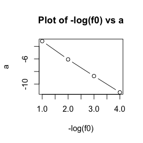

```r
# 设定随机数种子
set.seed(12345)

# 设定参数和常量
N <- 1e6      # 样本数量(Big enough)
b1 <- 0       # 回归系数 b1,b2,b3
b2 <- 1
b3 <- -1
f0_v <- c(0.1, 0.01, 0.001, 0.0001)  # f0值设定

# 生成随机变量
x1 <- rpois(N, lambda = 1)  # 从参数为1的泊松分布中生成随机数
x2 <- rexp(N, rate = 1)      # 从速率为1的指数分布中生成随机数
x3 <- sample(0:1, N, replace = TRUE)  # 从0和1中随机抽取，进行放回抽样

# 定义函数来计算alpha值
calculate_a <- function(f0) {
  g <- function(alpha) {
    tmp <- exp(-alpha - b1*x1 - b2*x2 - b3*x3)
    p <- 1 / (1 + tmp)
    mean(p) - f0  # 返回函数值
  }

  # 对于给定的f0值，使用uniroot函数寻找根（alpha）
  solution <- uniroot(g, c(-100, 100))
  alpha <- solution$root
  return(alpha)
}

# 对于每一个f0值计算并储存对应的a值
a_values <- sapply(f0_v, function(f0) calculate_a(f0))

# 绘图
plot(-log10(f0_v), a_values, type = "b", xlab = "-log(f0)", ylab = "a", main = "Plot of -log(f0) vs a")
```

### 9.4

```r
set.seed(2012)

rw.MS <- function(n, variance, x0, N) {
  # 存储样本序列
  x <- numeric(N)
  x[1] <- x0

  # 生成均匀分布的随机数
  u <- runif(N, -.5, .5)

  # 计算接受率R
  R <- 1 -  sign(u) * log(1 - 2 * abs(u))

  # 计数器
  k <- 0

  # 生成样本序列
  for (i in 2:N) {
    # 从建议分布中生成候选样本
    y <- rnorm(1, x[i - 1], sqrt(variance))

    # 计算接受率，并比较接受或拒绝候选样本
    if (R[i] <= dt(y, n) / dt(x[i - 1], n))
      x[i] <- y
    else {
      x[i] <- x[i - 1]
      k <- k + 1
    }
  }

  # 返回样本序列和拒绝比例
  return(list(x = x, rejection_rate = k / N))
}

n <- 3  # 目标学生t分布的自由度
N <- 2e3  # 生成的样本数量
variance <- c(0.05, 0.5, 1, 2, 20)  # 不同的建议分布的标准差
x0 <- 15  # 初始样本值

# 调用rw.MS函数，计算不同v值下的拒绝比例
results <- lapply(variance, function(v) {
  rw <- rw.MS(n, v, x0, N)
  return(data.frame(rejection_rate = 1 - rw$rejection_rate))
})

# 创建一个空的数据框用于存储结果
result_table <- matrix(nrow = 2, ncol = 5)
colnames(result_table) <- NULL

# 填充结果表格
for (i in 1:length(variance)) {
  result_table[1, i] <- variance[i]
  result_table[2, i] <- results[[i]]$rejection_rate
}

# 设置行标签
rownames(result_table) <- c("Variance", "Rejection Rate")

# 输出结果表格
print(result_table)
```

```
##                  [,1]  [,2]   [,3]   [,4]    [,5]
## Variance       0.0500 0.500 1.0000 2.0000 20.0000
## Rejection Rate 0.4885 0.485 0.4695 0.4545  0.3895
```

### 9.7

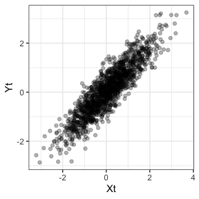

```r
# 库的加载
library(ggplot2)

# 参数设定
set.seed(2012)
N <- 2000    # 迭代数
burnin <- 500  # 烧入期
sigma <- matrix(c(1,0.9,0.9,1), nrow=2)  # 协方差矩阵
mu <- c(0,0)  # 均值设定为0

# Gibbs采样器
gibbs <- function(N, burnin, sigma, mu) {
  chain <- matrix(0, nrow=N, ncol=2)
  chain[1,] <- rnorm(2) # 先验设定

  for (i in 2:N) {
    chain[i,1] <- rnorm(1, mean=mu[1]+sigma[1,2]*((chain[i-1,2]-mu[2])/sigma[2,2]),
                        sd=sqrt(sigma[1,1]-sigma[1,2]^2/sigma[2,2]))
    chain[i,2] <- rnorm(1, mean=mu[2]+sigma[2,1]*((chain[i,1]-mu[1])/sigma[1,1]),
                        sd=sqrt(sigma[2,2]-sigma[2,1]^2/sigma[1,1]))
  }

  return(chain[-(1:burnin),])
}

chain <- gibbs(N, burnin, sigma, mu)

# 绘图
ggplot(data.frame(x=chain[,1], y=chain[,2]), aes(x=x, y=y)) +
  geom_point(alpha=0.3) +
  theme_bw() +
  labs(x="Xt", y="Yt")
```

```r
# 线性回归拟合
fit <- lm(y ~ x, data=data.frame(x=chain[,1], y=chain[,2]))

# 正态性检验
resids <- residuals(fit)
shapiro_test <- shapiro.test(resids)
print(shapiro_test)
```

```
##
##  Shapiro-Wilk normality test
##
## data:  resids
## W = 0.99899, p-value = 0.5847
```

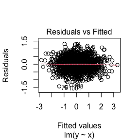

```r
# 残差的检查
resids <- residuals(fit)

# 残差和方差定性检验
plot(fit, which=1)  # Residuals vs Fitted
```

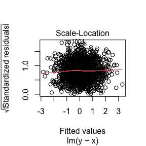

```r
plot(fit, which=3)  # Scale-Location (检查异方差性)
```

```
## Potential scale reduction factors:
##
##      Point est. Upper C.I.
## [1,]       1.06        1.2
```

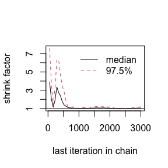

```r
library(coda)
set.seed(2012)

# 定义 Gelman.Rubin 函数，用于计算 Gelman-Rubin 统计量
Gelman.Rubin <- function(psi) {
  psi <- as.matrix(psi)
  n <- ncol(psi)
  k <- nrow(psi)
  psi.means <- rowMeans(psi) # 计算每个链的均值
  B <- n * var(psi.means) # 计算链间方差
  psi.w <- apply(psi, 1, var) # 计算链内方差
  W <- mean(psi.w) # 计算总体均值
  v.hat <- ((n - 1) / n) * W + B / n # 估计总体方差的上界
  r.hat <- v.hat / W # Gelman-Rubin 统计量
  return(r.hat)
}

# 定义 normal.chain 函数，用于生成正态分布的 Metropolis 迭代链
normal.chain <- function(sigma, N, X1) {
  x <- numeric(N)
  x[1] <- X1
  u <- runif(N, -0.5, 0.5) # 生成均匀分布的[0,1]上的随机数
  for (i in 2:N) {
    xt <- x[i-1]
    y <- rnorm(1, xt, sigma) # 生成候选点
    r1 <- dnorm(y, 0, 1) * dnorm(xt, y, sigma) # 计算比例 r1
    r2 <- dnorm(xt, 0, 1) * dnorm(y, xt, sigma) # 计算比例 r2
    r <- r1 / r2 # 比较 r1 和 r2
    if (u[i] <= r) {
      x[i] <- y
    } else {
      x[i] <- xt
    }
  }
  return(x)
}

run_until_converged <- function(sigma, k, n, b, x0) {
  X <- matrix(0, nrow=k, ncol=n)
  r.hat <- 1.2

  while (r.hat >= 1.2) {
    # 生成 Metropolis 迭代链
    for (i in 1:k) {
      X[i, ] <- normal.chain(sigma, n, x0)
    }

    # 计算诊断统计量
    psi <- t(apply(X, 1, cumsum)) # 计算累积和
    for (i in 1:nrow(psi)) {
      psi[i, ] <- psi[i, ] / (1:ncol(psi)) # 求均值
    }
    r.hat <- Gelman.Rubin(psi)

    # 若链未收敛，增加迭代次数
    if (r.hat >= 1.2) {
      n <- n + b
      X <- matrix(0, nrow=k, ncol=n)
    }
  }

  # 使用 coda 包进行检查
  mcmc_chains <- lapply(1:k, function(i) {
    mcmc(X[i,], start=1, end=n)
  })

  mcmc_list = mcmc.list(mcmc_chains) # 创建 mcmc.list
  gelman_diag = gelman.diag(mcmc_list) # 计算 Gelman-Rubin 诊断
  print(gelman_diag)
  gelman.plot(mcmc_list) # 绘制 Gelman-Rubin 图

  return(list(X=X, r.hat=r.hat))
}

# 调整参数
sigma <- 0.5 #正态分布标准差
k <- 3
n <- 2e3
b <- 1000
x0 <- 15

results <- run_until_converged(sigma, k, n, b, x0)
```

```r
cat("Gelman-Rubin 统计量:", results$r.hat)
```

```
## Gelman-Rubin 统计量: 1.041643
```

```r
sigma <- 2 #正态分布标准差
k <- 3
n <- 1e3
b <- 1000
x0 <- 15

results <- run_until_converged(sigma, k, n, b, x0)
```

```
## Potential scale reduction factors:
##
##      Point est. Upper C.I.
## [1,]       1.03       1.04
```

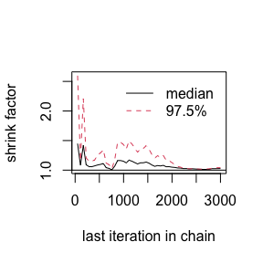

### HW8 2023/11/13

### Question

$1. \quad$ 设x1,…,xn 满足 EXP(λ)的独立同分布, 因为某种原因，只知道xi 落在某个区间（u_i , v_i),其中,u_i < v_i 是两个非随机的已知常数，这种数据称为区间删失数据。

• （1）试 分别直接极大化观测数据的似然函数与采用EM算法求解 λ 的MLE，证明EM算法收敛于观察数据的MLE，且收纳为线性速度。

• （2） 设（ui，vi），i=1，···，n(=10)的观测值为（11，12），（8，9），（27，28），（13，14），（16，17），（0，1），（23，24）， （10，11），（24，25）），（2，3）试分别编程实现上述两种算法以得到 λ 的MLE的数值解。

• 提示：观测数据的似然估计函数为 L(λ) = $\prod_{i=1}^{n}P_λ（u_i<= x_i<=v_i)$

$2. \quad$ Exercises 11.8 (pages 354, Statistical Computing with R).

In the Morra game, the set of optimal strategies are not changed if a constant is subtracted from every entry of the payoff matrix, or a positive constant is multiplied times every entry of the payoff matrix. However, the simplex algorithm may terminate at a different basic feasible point (also optimal). Compute B <- A + 2, find the solution of game B, and verify that it is one of the extreme points (11.12)–(11.15) of the original game A. Also find the value of game A and game B.

### Answer

### 1.

$直接极大化观测数据的似然函数: \quad$

由题设 $x_i$满足$f(x) \ =\ λe^{-λx}(x>0,λ>0)$

有
$$P_λ \ =\ e^{-λu_i}-e^{-λv_i}(u_i \leq
x_i \leq v_i)$$

则似然函数可表示$L(λ)\ = \ \prod_{i=1}^{n} e^{-λu_i}-e^{-λv_i}$

两边取对数可得
$$lnL(λ)\ = \ \sum_{i=1}^{n}
ln(e^{-λu_i}-e^{-λv_i})$$

那么通过求解$lnL(λ)$的最大值，则可以得到λ的MLE

$用EM算法求解: \quad$

由上文可知，对数似然函数$lnL(λ)\ = \ \sum_{i=1}^{n} ln(e^{-λu_i}-e^{-λv_i})$

E步：首先，自定义一个λ，然后计算每个interval的期望$E(x_i|u_i \leq x_i \leq v_i)$

根据指数分布的特性，其概率密度函数pdf 可表示
$$p_λ(x)\ = \
\frac{λe^{-λx}}{e^{-λu_i}-e^{-λv_i}}$$

故
$$E(x_i|u_i \leq x_i \leq v_i)=
\int_{u_i}^{v_i} \ x_i\frac{λe^{-λx}}{e^{-λu_i}-e^{-λv_i}}
dx$$

化简得，
$$E(x_i|u_i \leq x_i \leq v_i) =
\frac{λu_ie^{-λu_i}-λv_ie^{-λv_i}}{e^{-λu_i}-e^{-λv_i}}
+\ \frac{1}{λ}$$

M步：根据E步得，
$$λ_{t+1} \ =\
\frac{1}{E(x_i|u_i \leq x_i \leq v_i)} =
\frac{1}{\frac{λ_tu_ie^{-λ_tu_i}-λ_tv_ie^{-λ_tv_i}}{e^{-λ_tu_i}-e^{-λ_tv_i}}
+\ \frac{1}{λ_t}}$$

那么,当 lnL(λ) 收敛于λ时，即可得到λ 得MLE

现在证明EM算法收敛于观察数据的MLE，且收纳为线性速度。

由上文，
$$λ_{t+1} \ =
\frac{1}{\frac{1}{n}\sum_{i=1}^{n}\frac{λ_tu_ie^{-λ_tu_i}-λ_tv_ie^{-λ_tv_i}}{e^{-λ_tu_i}-e^{-λ_tv_i}}
+\ \frac{1}{λ_t}} = \ f(λ_{t})$$

设
$$g(λ) =
\frac{1}{n}\sum_{i=1}^{n}\frac{λ_tu_ie^{-λ_tu_i}-λ_tv_ie^{-λ_tv_i}}{e^{-λ_tu_i}-e^{-λ_tv_i}}$$

$令 g(λ^*) = \ 0$

那么$λ^*$ 为 f(λ) 的不动点，且满足 $λ_{t+1} = λ_{t}$ 即EM算法收敛

$$f'(λ) = -\frac{1}{(g(λ)+
\frac{1}{λ})^2}(g'(λ)-(\frac{1}{λ})^2)$$

则
$$f'(λ*) = 1- (λ^*)^2g'(λ*)=\
1-\frac{1}{n}\sum_{i=1}^{n}\frac{(λ(u_i-v_i))^2}{e^{λ(v_i-u_i)}+e^{λ(u_i-v_i)}
-2}$$

设$x_i = (λ(v_i-u_i)\ \ (x_i>0)$

有
$$f'(λ*) =
1-\frac{1}{n}\sum_{i=1}^{n}\frac{x_i^2}{e^{x_i}+e^{-x_i} -2}\\ =
1-\frac{1}{n}\sum_{i=1}^{n}(\frac{x_i}{e^{\frac{x_i}{2}}-e^{-\frac{x_i}{2}}})^2$$

显然 $\frac{x}{e^{\frac{x}{2}}-e^{-\frac{x}{2}}}>0$

由泰勒展开，
$$e^{\frac{x}{2}}-e^{-\frac{x}{2}} =
\sum_{n=0}^{∞}\frac{x^n}{(n)!2^n} -\sum_{n=0}^{∞}
\frac{(-1)^nx^n}{(n)!2^n}\\
=\sum_{n=0}^{∞}\frac{x^{2n+1}}{(2n+1)!2^{2n}} = x
+\sum_{n=1}^{∞}\frac{x^{2n+1}}{(2n+1)!2^{2n}}>x$$

即$\frac{x}{e^{\frac{x}{2}}-e^{-\frac{x}{2}}}<1$

故
$$0<\frac{1}{n}\sum_{i=1}^{n}(\frac{x_i}{e^{\frac{x_i}{2}}-e^{-\frac{x_i}{2}}})^2<1$$

即
$$0<f'(λ*) =
1-\frac{1}{n}\sum_{i=1}^{n}(\frac{x_i}{e^{\frac{x_i}{2}}-e^{-\frac{x_i}{2}}})^2<1$$

因此该EM算法有线性收敛速度

```r
# 模拟生成数据
set.seed(123)

u <- c(11, 8, 27, 13, 16, 0, 23, 10, 24, 2)
v <- c(12, 9, 28, 14, 17, 1, 24, 11, 25, 3)

# Define negative log-likelihood function
nll <- function(lambda) {
  return (-sum(log(exp(-lambda * u) - exp(-lambda * v))))
}
#res <- optimize(-nll,lower=0,upper=8,maximum=TRUE)
#res$maximum
result <- optim(0.01, nll, method = "L-BFGS-B")


cat("直接极大化观测数据的似然函数得到 λ的MLE：",round(result$par,6))
```

```
## 直接极大化观测数据的似然函数得到 λ的MLE： 0.071977
```

```r
#设置初始值
set.seed(123)

u <- c(11, 8, 27, 13, 16, 0, 23, 10, 24, 2)
v <- c(12, 9, 28, 14, 17, 1, 24, 11, 25, 3)

lambda <- 20
iteration_gap <- 1e-6

# 定义一个函数来计算E-step
compute_expectation <- function(u, v, lambda) {
  num1 <- ((-v-(1/lambda))*exp(-lambda*v) + (u+(1/lambda))*exp(-lambda*u))
  den <-(exp(-lambda * u) - exp(-lambda * v))
  return (num1 / den)
}

LogLikelihoodFunc <- function(lambda, u, v) {
  return (sum(log(exp(-lambda * u) - exp(-lambda * v)+0.9764)))
}#

# 开始迭代
while(TRUE){
  old_lambda <- lambda
  # E-step
  e_step <- compute_expectation(u, v, lambda)
  # M-step

  lambda <- 1/mean(e_step)

  #新得到的lambda
  new_lambda <- LogLikelihoodFunc(lambda, u, v)

  # 检查是否收敛
  if(abs(new_lambda - old_lambda) < iteration_gap) break

  # 更新 lambda
  lambda <- new_lambda
}

# 输出 lambda 的 MLE
cat("EM算法得到 λ的MLE：",round(lambda,6))
```

```
## EM算法得到 λ的MLE： 0.071977
```

### 11.8

```r
## 加载资源包
library(plyr)
library(lpSolve)
library(boot)
# 定义用于解决零和博弈的函数 solve.game
solve.game <- function(A) {
  # 解决两人零和博弈，使用单纯形法
  # 优化玩家1，然后玩家2
  # 最大化 v 使得 ...
  # 让 x 代表策略 1:m，v 作为额外变量
  # A1，是 <= 约束
  #
  min.A <- min(A)
  A <- A - min.A # 使得 v >= 0
  max.A <- max(A)
  A <- A / max.A
  m <- nrow(A)
  n <- ncol(A)
  it <- n^3
  a <- c(rep(0, m), 1) # 目标函数
  A1 <- -cbind(t(A), rep(-1, n)) # 约束 <=
  b1 <- rep(0, n)
  A3 <- t(as.matrix(c(rep(1, m), 0))) # 约束 sum(x)=1
  b3 <- 1
  sx <- simplex(a=a, A1=A1, b1=b1, A3=A3, b3=b3,
                maxi=TRUE, n.iter=it)
  # 解的 [x1,x2,...,xm | 博弈的值]
  #
  # 最小化 v 使得 ...
  # 让 y 代表策略 1:n，v 为额外变量
  a <- c(rep(0, n), 1) # 目标函数
  A1 <- cbind(A, rep(-1, m)) # 约束 <=
  b1 <- rep(0, m)
  A3 <- t(as.matrix(c(rep(1, n), 0))) # 约束 sum(y)=1
  b3 <- 1
  sy <- simplex(a=a, A1=A1, b1=b1, A3=A3, b3=b3,
                maxi=FALSE, n.iter=it)
  soln <- list("A" = A * max.A + min.A,
               "x" = sx$soln[1:m],
               "y" = sy$soln[1:n],
               "v" = sx$soln[m+1] * max.A + min.A)
  soln
}

# 定义 payoff matrix A
matrixA  <- matrix(c( 0,-2,-2,3,0,0,4,0,0,
                      2,0,0,0,-3,-3,4,0,0,
                      2,0,0,3,0,0,0,-4,-4,
                      -3,0,-3,0,4,0,0,5,0,
                      0,3,0,-4,0,-4,0,5,0,
                      0,3,0,0,4,0,-5,0,-5,
                      -4,-4,0,0,0,5,0,0,6,
                      0,0,4,-5,-5,0,0,0,6,
                      0,0,4,0,0,5,-6,-6,0), 9, 9)

# 创建 payoff matrix B
matrixB <- matrixA + 2

# 计算 game A 的结果
sA <- solve.game(matrixA)

# 计算 game B 的结果
sB <- solve.game(matrixB)

# 输出最优策略
round(cbind(sB$x,sB$y),7)
```

```
##         [,1]      [,2]
## x1 0.0000000 0.0000000
## x2 0.0000000 0.0000000
## x3 0.4098361 0.4098361
## x4 0.0000000 0.0000000
## x5 0.3278689 0.3278689
## x6 0.0000000 0.0000000
## x7 0.2622951 0.2622951
## x8 0.0000000 0.0000000
## x9 0.0000000 0.0000000
```

```r
print("Apparently， the solution of game B is the extreme points (11.15) of the original game A. ")
```

```
## [1] "Apparently， the solution of game B is the extreme points (11.15) of the original game A. "
```

```r
# 比较博弈 A 和 B 的值
cat("Game A value: ", sA$v, "\n")
```

```
## Game A value:  0
```

```r
cat("Game B value: ", sB$v, "\n")
```

```
## Game B value:  2
```

### HW9 2023/11/20

### Question

$1. \quad$

• 2.1.3 Exercise 4 (Pages 19 Advanced in R)

• 2.3.1 Exercise 1, 2 (Pages 26 Advanced in R)

• 2.4.5 Exercise 2, 3 (Pages 30 Advanced in R)

• Exercises 2 (page 204, Advanced R)

• Exercises 1 (page 213, Advanced R)

$2.1.3 Exercise 4 (Pages 19 Advanced in R) \quad$

Why do you need to use unlist() to convert a list to an atomic vector? Why doesn’t as.vector() work?

$2.3.1 Exercise 1, 2 (Pages 26 Advanced in R) \quad$

• 1. What does dim() return when applied to a vector?

• 2. If is.matrix(x) is TRUE, what will is.array(x) return? install.packages(‘roxygen2’,dependencies = TRUE)

$2.4.5 Exercise 2, 3 (Pages 30 Advanced in R) \quad$

• 2. What does as.matrix() do when applied to a data frame with columns of different types?

• 3. Can you have a data frame with 0 rows? What about 0 columns?

$Exercises 2 (page 204, Advanced R)\quad$

The function below scales a vector so it falls in the range [0,1]. How would you apply it to every column of a data frame? How would you apply it to every numeric column in a data frame?

scale01 <- function(x) { rng <- range(x, na.rm = TRUE) (x - rng[1]) / (rng2 - rng[1]) }

$Exercises\ 1\ \quad$

Use vapply() to:

• a) Compute the standard deviation of every column in a numeric data frame.

• b) Compute the standard deviation of every numeric column in a mixed data frame. (Hint: you’ll need to use vapply() twice.)

$2. \quad$ Consider Exercise 9.8 (pages 278, Statistical Computing with R). (Hint: Refer to the first example of Case studies section)

• Write an R function.

• Write an Rcpp function.

• Compare the computation time of the two functions with the function “microbenchmark”.

### Answer

### 2.1.3 Exercise 4

• as.vector()函数在将列表转换为向量时，会按照特定的顺序展开列表的元素，并创建一个具有相同顺序的向量。 转换为列表的结果可能不是预期的原子向量，而是一个以列表形式表示的向量。

• 原子向量是R中的基本数据类型，许多函数和操作要求输入为原子向量而非列表。

• unlist()函数能够递归地将列表的所有元素提取出来，并按照顺序排列，返回一个原子向量。 使用unlist()函数可以确保得到正确的结果，将列表转换为原子向量。

### 2.3.1 Exercise 1, 2

• 当dim()函数应用于一个向量时，它会返回NULL。向量是一维的数据结构，没有维度属性，因此dim()函数返回NULL表示没有维度信息可获得。

• 当使用is.matrix(x)判断一个对象x是否为矩阵时，如果返回值为TRUE，表示x是一个矩阵。如果应用is.array(x)函数来判断对象x是否为数组，返回值也将是TRUE。这是因为矩阵是数组的一种特殊形式，所有的矩阵也都是数组，因此对于一个矩阵，is.array(x)的返回值也将是TRUE。

### 2.4.5 Exercise 2, 3

• 当将as.matrix()函数应用于具有不同类型列的数据框时，数据框中的每列将被转换为矩阵中的一个子矩阵。每个子矩阵的类型将由该列的数据类型确定。将数据帧转换为矩阵时，R将试图将所有的列转换为相同的数据类型，但如果列之间的数据类型不兼容，则数据框中的每列将以相应的子矩阵形式存在于矩阵中。

• 可以创建一个具有零行的数据框，但无法创建具有零列的数据框。一个具有零行的数据框在R中是有效的，表示该数据框没有任何观察值或记录。但在数据框中至少需要一个变量（列）来表示属性，因此无法创建一个没有任何列的数据框。至少需要一个变量（列）来定义数据框的结构。

### Exercises 2

```r
# 加载 plyr 包
library(plyr)

# 创建一个数据框

df <- data.frame(
  A = c(10, 20, 30, 40),
  B = c(1.5, 2.5, 3.5, 4.5),
  C = c(100, 200, 300, 400)
)

scale01 <- function(x) {
  rng <- range(x, na.rm = TRUE)
(x - rng[1]) / (rng[2] - rng[1])
}

# apply it to every column of a data frame
scaled_df <- apply(df, 2, scale01)
scaled_df
```

```
##              A         B         C
## [1,] 0.0000000 0.0000000 0.0000000
## [2,] 0.3333333 0.3333333 0.3333333
## [3,] 0.6666667 0.6666667 0.6666667
## [4,] 1.0000000 1.0000000 1.0000000
```

```r
# 列wise函数，用于数值型列
scale01_numeric <- colwise(scale01)

# 对数据框中的数值列应用缩放函数
scaled_df <- scale01_numeric(df)

# 输出结果
scaled_df
```

```
##           A         B         C
## 1 0.0000000 0.0000000 0.0000000
## 2 0.3333333 0.3333333 0.3333333
## 3 0.6666667 0.6666667 0.6666667
## 4 1.0000000 1.0000000 1.0000000
```

### Exercises 1

```r
# 创建一个数值数据框
numeric_df <- data.frame(
  A = c(10, 20, 30, 40),
  B = c(1.0, 2.0, 3.0, 4.0),
  C = c(100, 200, 300, 400)
)

# 计算每列的标准差
sd_numeric <- vapply(numeric_df, sd, numeric(1))
cat("the standard deviation of every column in a numeric data frame:",sd_numeric,"\n")
```

```
## the standard deviation of every column in a numeric data frame: 12.90994 1.290994 129.0994
```

```r
# 创建一个包含数值和非数值列的混合数据框
mixed_df <- data.frame(
  A = c(10, 20, 30, 40),
  B = c("apple", "banana", "orange", "grape"),
  C = c(1.5, 2.5, 3.5, 4.5),
  D = c("red", "green", "blue", "yellow")
)

# 确定数值列
numeric_cols <- sapply(mixed_df, is.numeric)

# 计算每个数值列的标准差
sd_mixed <- vapply(mixed_df[, numeric_cols], sd, numeric(1))
cat("the standard deviation of every numeric column in a mixed data frame:",sd_mixed)
```

```
## the standard deviation of every numeric column in a mixed data frame: 12.90994 1.290994
```

### 2

```r
library(microbenchmark)
gibbs_sampler <- function(a, b, n, iter=1000) {
  x <- rep(0, iter) # 初始化x向量
  y <- rep(0, iter) # 初始化y向量

  # 初始化参数
  x[1] <- 0
  y[1] <- rbeta(1, a, b)

  for (i in 2:iter) {
    # 样本x | y
    x[i] <- rbinom(1, n, y[i-1])
    # 样本y | x
    y[i] <- rbeta(1, x[i] + a, n - x[i] + b)
  }
  return(data.frame(x, y))
}

library(Rcpp)
dir_cpp <- '/Users/liujt/Downloads/mcmc 2/'
# 使用sourceCpp函数，先编写一个C++源文件，然后将它嵌入到R中
sourceCpp(paste0(dir_cpp,"gibbs_sampler.cpp"))

# 设置测试参数
a <- 1
b <- 3
n <- 12
iter <- 1000

result <- microbenchmark(
  R = gibbs_sampler(a, b, n, iter),
  Rcpp = gibbs_sampler_cpp(a, b, n, iter),
  times = 10
)
print(result)
```

```
## Unit: microseconds
##  expr      min       lq      mean   median       uq      max neval
##     R 2234.787 2341.141 2717.7137 2366.294 2446.798 5889.404    10
##  Rcpp  182.327  188.067  248.2386  190.486  197.128  697.082    10
```